# Meeting Engagement Drivers with Viva Insights in R

2026-07-01

```r
knitr::opts_chunk$set(warning = FALSE, message = FALSE)
library(tidyverse)
library(vivainsights)
library(randomForest)   # random forests, matching the repo's existing RF example
```

# Meeting Engagement Drivers

## Introduction

Many meeting-culture conversations start with *“we have too many meetings”*. A more useful question is often *“are we meeting **well**?”*, that is, are the people in a meeting actually engaged, or are they quietly working on something else while it runs?

Viva Insights captures a few behavioural signals for every meeting that let us approximate engagement, including the number of attendees multitasking and the number of **chats and emails sent during the meeting**. In this example we treat in-meeting messaging as a proxy for disengagement (a busy backchannel usually means people are only half-present) and ask a simple modelling question: **which characteristics of a meeting best predict how much backchannel messaging it generates?**

We will:

1. Prepare a simulated meeting-level dataset shaped like a Meeting Query.
2. Fit a random forest to rank the design features that drive per-attendee messaging.
3. Take a closer look at the top driver (meeting duration) and separate a genuine effect from the trivial “a longer meeting simply has more minutes” explanation.

Everything below runs on a small **simulated** Meeting Query created inside this document, so it is fully reproducible with no data of your own. The package does ship a sample Meeting Query (`vivainsights::mt_data`), but it is small and mostly single-person focus blocks, so it lacks the multi-person meetings and in-meeting messaging this model needs. We use a seeded simulation instead, built with the same column names as a real Meeting Query, so that the identical downstream code runs on your own export.

## Set-up and data preparation

We begin by simulating a Meeting Query. The data-generating process makes **duration the dominant driver** of messaging, with a sub-linear (exponent < 1) relationship, so total messaging rises with length while per-minute messaging gently declines, which creates a plausible pattern for demonstration. The column names match a real Meeting Query, so to run this on your own tenant you can replace `simulate_meeting_query()` with `vivainsights::import_query("your_meeting_query.csv")`. (The shipped `vivainsights::mt_data` is handy for inspecting the expected schema, but is too small and focus-block-heavy to fit this model.)

```r
simulate_meeting_query <- function(n = 2000, seed = 42) {
  set.seed(seed)
  duration_min <- sample(c(15, 30, 45, 60, 90, 120, 180), n, replace = TRUE,
                         prob = c(.14, .28, .20, .18, .10, .06, .04))
  n_attendees  <- 2 + rpois(n, 4)                 # at least 2
  intended     <- n_attendees + rpois(n, 1)
  recurring    <- rbinom(n, 1, 0.5)
  accept       <- rbinom(n, intended, 0.70)       # RSVP responses out of invitees
  remaining    <- intended - accept
  no_response  <- rbinom(n, remaining, 0.60)
  decline      <- remaining - no_response
  redundant    <- rbinom(n, n_attendees, 0.10)
  no_response_rate <- no_response / pmax(intended, 1)

  # Per-attendee messaging rate: duration dominates, sub-linearly (^0.85)
  lam <- 0.03 * duration_min^0.85 *
    (1 + 0.8 * no_response_rate) *
    (1 + 0.05 * log(n_attendees))
  chats  <- rpois(n, lam * 0.5 * n_attendees)
  emails <- rpois(n, lam * 0.5 * n_attendees)

  tibble::tibble(
    Number_of_attendees                      = n_attendees,
    Number_of_attendees_multitasking         = rbinom(n, n_attendees, 0.3),
    Number_of_chats_sent_during_the_meeting  = chats,
    Number_of_emails_sent_during_the_meeting = emails,
    Number_of_redundant_attendees            = redundant,
    All_Day_Meeting                          = "FALSE",
    Cancelled                                = "FALSE",
    Recurring                                = ifelse(recurring == 1, "TRUE", "FALSE"),
    Accept_count                             = accept,
    No_response_count                        = no_response,
    Decline_count                            = decline,
    Intended_participant_count               = intended,
    Duration                                 = duration_min / 60   # Duration is in HOURS
  )
}

# On your own data, replace this line with an exported Meeting Query, e.g.
#   vivainsights::import_query("your_meeting_query.csv")
mt_raw <- simulate_meeting_query()
```

Now a light quality filter to keep genuine meetings only, dropping solo calendar blocks, cancelled items, and all-day entries. (On your own data you would apply a fuller cleaning step; the point here is simply to model real meetings.)

```r
# Coerce the TRUE/FALSE flags robustly (they may load as strings)
as_flag <- function(x) as.logical(as.character(x))

mt <- mt_raw %>%
  mutate(
    Cancelled       = as_flag(Cancelled),
    All_Day_Meeting = as_flag(All_Day_Meeting),
    Recurring       = as_flag(Recurring)
  ) %>%
  filter(
    Number_of_attendees >= 2,   # drop solo holds / focus blocks
    !Cancelled,
    !All_Day_Meeting,
    Duration > 0
  )

nrow(mt)
```

```
## [1] 2000
```

Next we engineer the modelling frame. Note that `Duration` in a Meeting Query is expressed in **hours**, so we convert it to minutes for readability. We normalise the messaging counts **per attendee** so that large meetings do not automatically look busier, and we derive a few RSVP “commitment” signals (what share of invitees accepted, did not respond, or declined) that often turn out to matter.

```r
model_df <- mt %>%
  transmute(
    # --- outcomes: in-meeting messaging per attendee ---
    chats_per_att   = Number_of_chats_sent_during_the_meeting  / Number_of_attendees,
    emails_per_att  = Number_of_emails_sent_during_the_meeting / Number_of_attendees,

    # --- candidate design predictors ---
    duration_min          = Duration * 60,
    n_attendees           = Number_of_attendees,
    intended_participants = Intended_participant_count,
    recurring             = factor(Recurring),
    accept_rate           = Accept_count      / pmax(Intended_participant_count, 1),
    no_response_rate      = No_response_count  / pmax(Intended_participant_count, 1),
    decline_rate          = Decline_count      / pmax(Intended_participant_count, 1),
    redundant_share       = Number_of_redundant_attendees / pmax(Number_of_attendees, 1)
  ) %>%
  drop_na()

head(model_df)
```

```
## # A tibble: 6 × 10
##   chats_per_att emails_per_att duration_min n_attendees intended_participants
##           <dbl>          <dbl>        <dbl>       <dbl>                 <dbl>
## 1         0.818          1.55           120          11                    12
## 2         0.667          0.333          120           6                     9
## 3         1.14           0.143           45           7                     8
## 4         1              0.375           90           8                    10
## 5         0.75           0.375           60           8                     8
## 6         1              1.14            60           7                     8
## # ℹ 5 more variables: recurring <fct>, accept_rate <dbl>,
## #   no_response_rate <dbl>, decline_rate <dbl>, redundant_share <dbl>
```

## Ranking the drivers with a random forest

We fit a random forest with the **randomForest** package (the same package used in this repo’s top-performers example), setting `importance = TRUE` so we can read off permutation-based importance, the `%IncMSE`, i.e. how much the prediction error rises when each feature is shuffled. Random forests capture non-linear effects and interactions without us specifying them.

We fit one model per outcome (chats per attendee and emails per attendee), which mirrors the idea that chat and email backchannels can behave a little differently.

```r
set.seed(123)

predictors <- c("duration_min", "n_attendees", "intended_participants",
                "recurring", "accept_rate", "no_response_rate",
                "decline_rate", "redundant_share")

rf_chats <- randomForest::randomForest(
  x          = model_df[predictors],
  y          = model_df$chats_per_att,
  ntree      = 500,
  importance = TRUE
)

rf_emails <- randomForest::randomForest(
  x          = model_df[predictors],
  y          = model_df$emails_per_att,
  ntree      = 500,
  importance = TRUE
)
```

The out-of-bag (OOB) R-squared tells us how much of the variation in messaging the features explain. For human behaviour, modest values are entirely expected, and we report them as an **association**, not a causal effect.

```r
tibble(
  outcome = c("chats per attendee", "emails per attendee"),
  oob_rsq = c(tail(rf_chats$rsq, 1), tail(rf_emails$rsq, 1))
)
```

```
## # A tibble: 2 × 2
##   outcome             oob_rsq
##   <chr>                 <dbl>
## 1 chats per attendee    0.463
## 2 emails per attendee   0.450
```

Now the part we care about: the ranked importance of each design feature. We plot the permutation importance (`%IncMSE`) for the chats model (the more differentiating of the two signals).

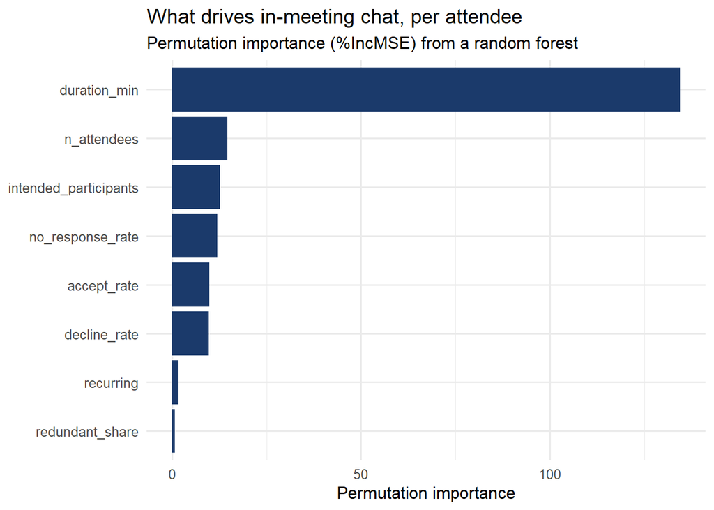

```r
imp_df <- tibble(
  feature    = rownames(randomForest::importance(rf_chats)),
  importance = randomForest::importance(rf_chats)[, "%IncMSE"]
) %>%
  arrange(importance)

ggplot(imp_df, aes(x = importance, y = reorder(feature, importance))) +
  geom_col(fill = "#1B3A6B") +
  labs(
    title = "What drives in-meeting chat, per attendee",
    subtitle = "Permutation importance (%IncMSE) from a random forest",
    x = "Permutation importance", y = NULL
  ) +
  theme_minimal(base_size = 12)
```

Typically **meeting duration ranks at or near the top**, alongside meeting size and the RSVP commitment signals. That already points at a practical lever, because duration is one of the few meeting properties you can change with a single calendar setting.

## A closer look at duration

Whenever “longer meetings have more messaging” comes up, a fair objection follows: *isn’t that trivial, since a longer meeting simply contains more minutes in which to send a message?* It is worth testing directly rather than assuming, because the answer changes the recommendation.

We group meetings into duration bands and compute messaging two ways: the **total** per attendee, and the same figure **per minute**. If the per-minute rate were flat, the total would be pure exposure (just more minutes). If it varies, something more interesting is going on.

```r
dose <- model_df %>%
  mutate(
    msgs_per_att = chats_per_att + emails_per_att,
    band = cut(
      duration_min,
      breaks = c(0, 15, 30, 60, 120, Inf),
      labels = c("<=15m", "16-30m", "31-60m", "61-120m", ">120m"),
      right  = TRUE
    )
  ) %>%
  group_by(band) %>%
  summarise(
    n_meetings          = n(),
    msgs_per_att        = mean(msgs_per_att, na.rm = TRUE),
    msgs_per_att_permin = mean(msgs_per_att / duration_min, na.rm = TRUE),
    .groups = "drop"
  )

dose
```

```
## # A tibble: 5 × 4
##   band    n_meetings msgs_per_att msgs_per_att_permin
##   <fct>        <int>        <dbl>               <dbl>
## 1 <=15m          280        0.354              0.0236
## 2 16-30m         593        0.647              0.0216
## 3 31-60m         726        1.05               0.0207
## 4 61-120m        332        1.91               0.0189
## 5 >120m           69        3.06               0.0170
```

The usual pattern is that **total messaging per attendee rises with length**, while the **per-minute rate is roughly flat or gently declining**. In other words, longer meetings are not disproportionately distracting minute-for-minute, but disengagement does not correct itself either: once people drift into the backchannel they tend to stay there, so the distraction accumulates across a long session.

A simple linear model gives us the marginal effect of length, holding meeting size constant, as an interpretable companion to the forest.

```r
lm_dur <- lm(
  I(chats_per_att + emails_per_att) ~ duration_min + n_attendees,
  data = model_df
)

# Extra messages per attendee for each additional 30 minutes
coef(lm_dur)[["duration_min"]] * 30
```

```
## [1] 0.5024913
```

## What this means

A few transferable practices for this kind of analysis:

- Model engagement friction at the **meeting level**, not the person level, and normalise messaging **per attendee** so meeting size does not dominate.
- Use permutation importance to rank drivers, then corroborate the top one with an interpretable model.
- Always split a “bigger total” finding into **rate** and **exposure** before making a claim about it.
- State results as **association, not causation**, and report the modest variance explained honestly.

Finally, there is a natural link to AI adoption. Some in-meeting messaging is simply people trying to stay productive while stuck in a session that does not need all of them. Capabilities such as Microsoft 365 Copilot meeting recaps let people skip or leave lower-value meetings and catch up afterwards, which is complementary to shortening meetings: one removes the room for disengagement, the other removes the reason for it. A useful extension is to test whether higher Copilot adoption is associated with a lighter backchannel in long meetings.